# Gapminder_Income_EDA

Logeshwar Venkatesan

20 February, 2019

# Target of this analysis

In this analysis, we will look at the variable income and understand how it affects three other important variables viz., population, life expectancy and geography.

## Data exploration

Load csv and read in data

```r
    library(readr)
    gapminder<-read_csv('gapminder.csv', col_types = 'cnnnnc')
```

## Check packaging

Check number of rows and columns in data set

```r
    nrow(gapminder)
```

```
## [1] 41284
```

```r
    ncol(gapminder)
```

```
## [1] 6
```

## Run str()

Analyze the internal structure of the R object

```r
    str(gapminder)
```

```
## Classes 'spec_tbl_df', 'tbl_df', 'tbl' and 'data.frame': 41284 obs. of  6 variables:
##  $ Country   : chr  "Afghanistan" "Afghanistan" "Afghanistan" "Afghanistan" ...
##  $ Year      : num  1800 1801 1802 1803 1804 ...
##  $ life      : num  28.2 28.2 28.2 28.2 28.2 ...
##  $ population: num  3280000 NA NA NA NA NA NA NA NA NA ...
##  $ income    : num  603 603 603 603 603 603 603 603 603 603 ...
##  $ region    : chr  "South Asia" "South Asia" "South Asia" "South Asia" ...
##  - attr(*, "spec")=
##   .. cols(
##   ..   Country = col_character(),
##   ..   Year = col_number(),
##   ..   life = col_number(),
##   ..   population = col_number(),
##   ..   income = col_number(),
##   ..   region = col_character()
##   .. )
```

Look at the top and bottom of the data to check formatting errors

```r
    head(gapminder)
```

```
## # A tibble: 6 x 6
##   Country      Year  life population income region
##   <chr>       <dbl> <dbl>      <dbl>  <dbl> <chr>
## 1 Afghanistan  1800  28.2    3280000    603 South Asia
## 2 Afghanistan  1801  28.2         NA    603 South Asia
## 3 Afghanistan  1802  28.2         NA    603 South Asia
## 4 Afghanistan  1803  28.2         NA    603 South Asia
## 5 Afghanistan  1804  28.2         NA    603 South Asia
## 6 Afghanistan  1805  28.2         NA    603 South Asia
```

```r
    tail(gapminder)
```

```
## # A tibble: 6 x 6
##   Country  Year  life population income region
##   <chr>   <dbl> <dbl>      <dbl>  <dbl> <chr>
## 1 Åland    1992  80.8      24834     NA Europe & Central Asia
## 2 Åland    1993  81.8      24950     NA Europe & Central Asia
## 3 Åland    1994  80.6      25066     NA Europe & Central Asia
## 4 Åland    1995  79.9      25183     NA Europe & Central Asia
## 5 Åland    1996  80        25301     NA Europe & Central Asia
## 6 Åland    1997  80.1      25419     NA Europe & Central Asia
```

## Check missing data

### Count of missing values

```r
    sapply(gapminder, function(x) sum(is.na (x)))
```

```
##    Country       Year       life population     income     region
##          0          0          0      25817       2341          0
```

## Data aggregation

```r
    library(dplyr)
    gapminder %>%
    group_by(Country) %>%
    summarise(life = median(life))
```

```
## # A tibble: 197 x 2
##    Country              life
##    <chr>               <dbl>
##  1 Afghanistan          28.0
##  2 Åland                80.0
##  3 Albania              35.4
##  4 Algeria              28.8
##  5 Andorra              81.1
##  6 Angola               27.0
##  7 Antigua and Barbuda  33.5
##  8 Argentina            41.5
##  9 Armenia              36.2
## 10 Aruba                34.4
## # ... with 187 more rows
```

## Plotting

### Total Dataset

In this section, we will plot a graph to understand the overall dataset and in the later sections, we will look at the questions we formulated.

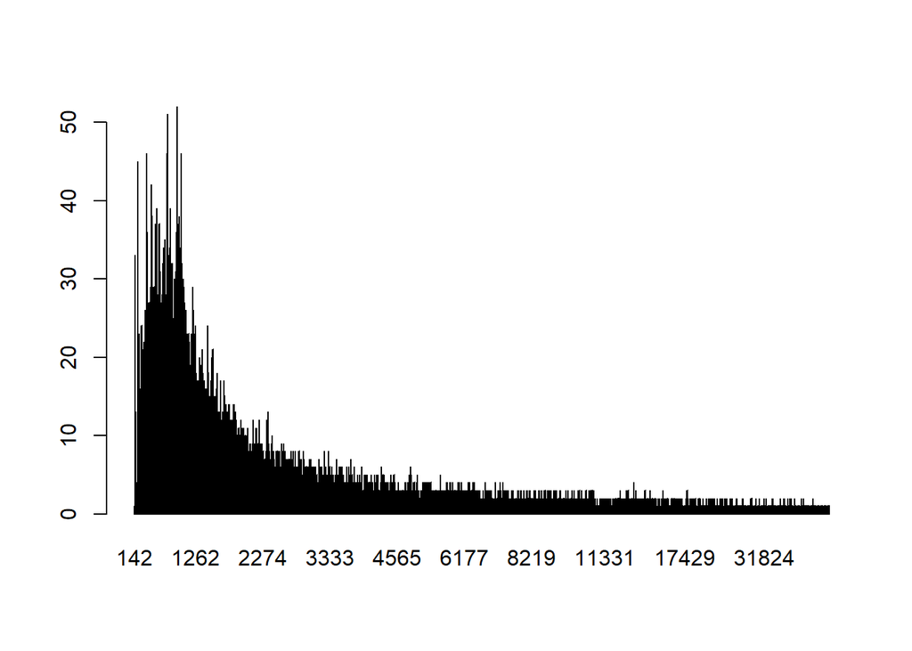

```r
    library(dplyr)
    table(gapminder$income) %>% barplot(col = "wheat")
```

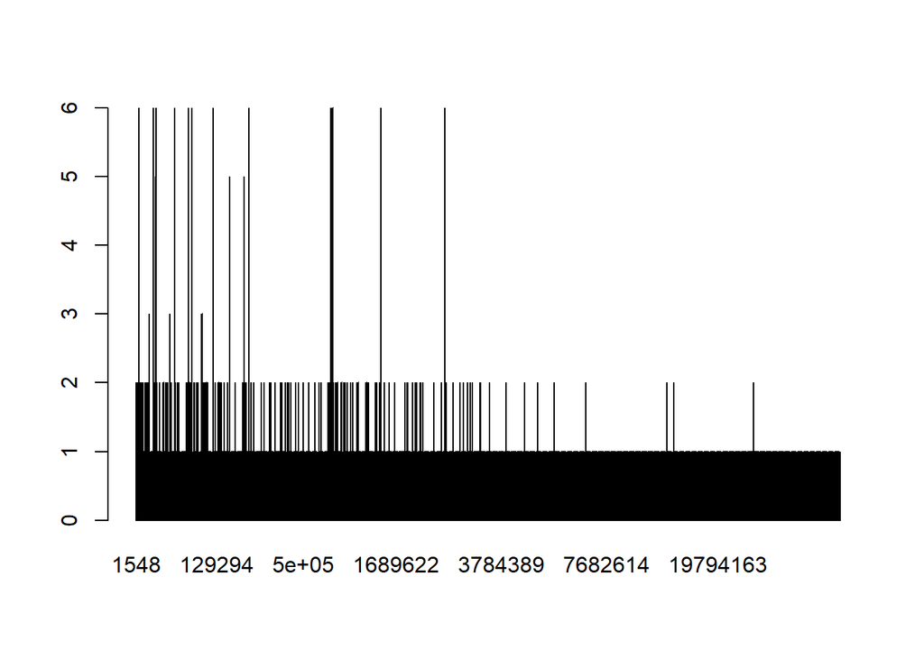

```r
    table(gapminder$population) %>% barplot(col = "wheat")
```

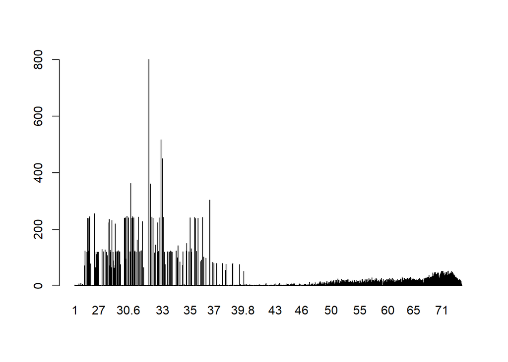

```r
    table(gapminder$life) %>% barplot(col = "wheat")
```

### Finite Dataset

**The analysis conducted is only after the year 2000 and hence we’ll filter the data accordingly**

Filter data from main dataset to include data for only after year 2000

```r
    library(tidyverse)
```

```r
    library(ggplot2)
    library(dplyr)
    gapminder2000<-filter(gapminder, Year >= 2000)
```

1. How does income relate to life expectancy?

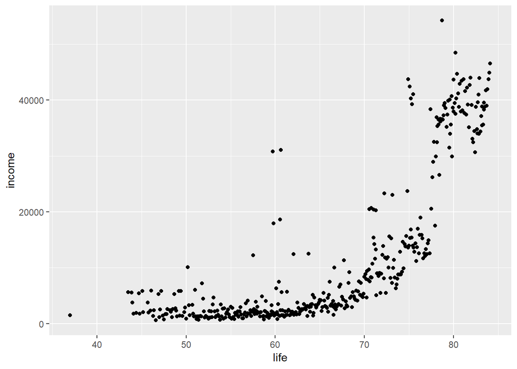

```r
    p1d<-aggregate(income ~ life, gapminder2000, median)
    library(ggplot2)
    p1<-qplot(life, income, data = p1d)
    p1
```

2. What is the population trend for United States vs India?

Filter and aggregate data for USA and India

```r
    gapminder2000AI <- filter(gapminder2000, Country == 'United States' | Country == 'India')

    p2d<-aggregate(Country ~ population, gapminder2000AI, median)
```

**Scatter plot of Population by Country**

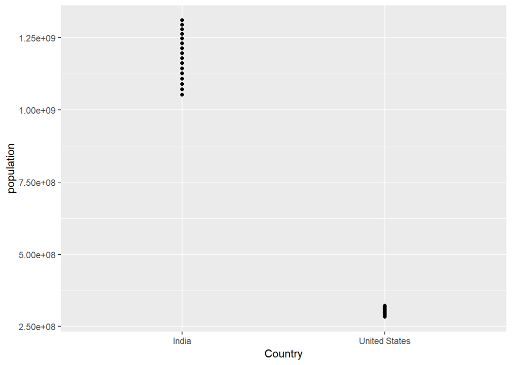

```r
    library(ggplot2)
    p2<-qplot(Country, population, data = p2d)
    p2
```

**Box plot of Population by Country**

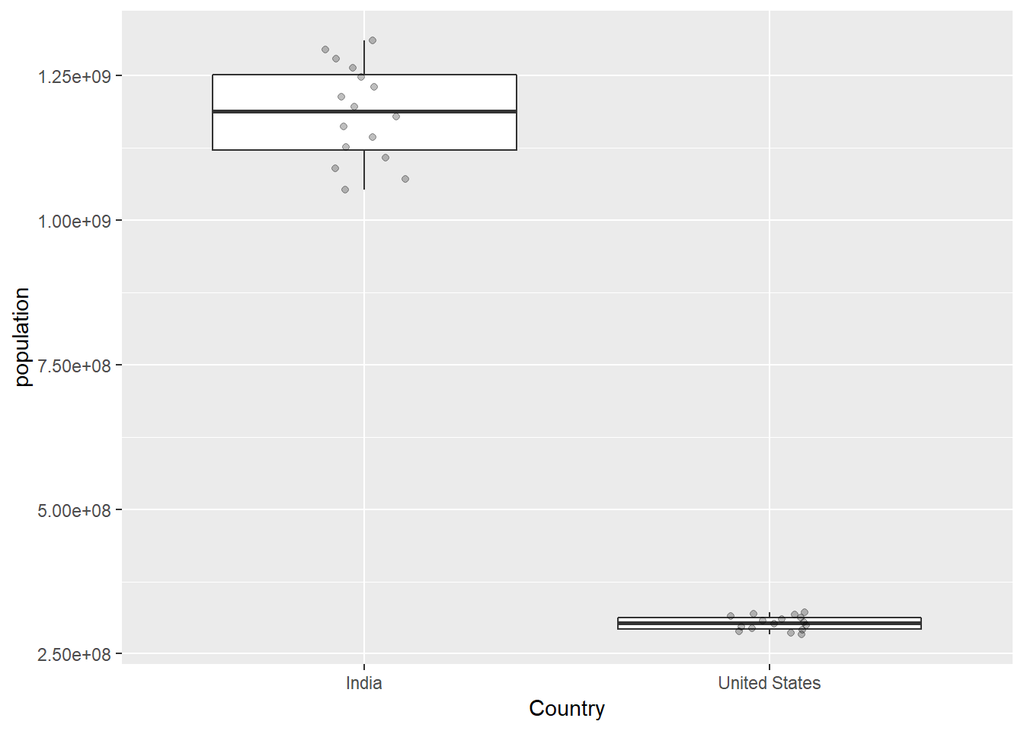

```r
    library(ggplot2)
    ggplot(p2d, aes(x = Country, y = population)) +
    geom_boxplot(outlier.colour = "hotpink") +
    geom_jitter(position = position_jitter(width = 0.1, height = 0), alpha = 1/4)
```

3. Top 10 and bottom 10 countries by income